# Weekly Energy Charts

December 16, 2022

Sign up to receive our email updates via [Substack](https://leach.substack.com/)

[interactive chart not shown]

# Featured Stories

## Fusion Achieved!?

#### [Yousaff Habib](https://www.linkedin.com/in/yousaff-habib-6684891a5/)

Hold onto your hats folks because this one is going to be a bit longer than normal.

Why? This week saw a major breakthrough in nuclear fusion.

Research into fusion began in the 1940s but, this week, after nearly 80 years of work, scientists were able to create a fusion reaction in a laboratory setting that produced more energy than it took to start the reaction. Think of this as creating, at a very small scale, a star. This marks the first time that this threshold, known as ignition, has been reached in a laboratory setting.

Fusion is the process by which hydrogen atoms are combined into helium, producing sunlight and warmth in stars. If it can be harnessed on a large scale, fusion could provide a virtually limitless and clean energy source, with no pollution or greenhouse gases produced, and no dangerous, long-lived radioactive waste.

The experiment at the National Ignition Facility used 192 giant lasers to blast a small cylinder containing hydrogen encased in diamond, generating an inward onslaught of X-rays that compressed a fuel pellet made of deuterium and tritium. The reaction produced 2.05 megajoules of energy, roughly the equivalent of a pound of TNT, and released a flood of neutron particles, the product of fusion. This achievement is a significant step towards the practical application of fusion energy. However, while it is a major step forward, we still have a great deal of issues regarding fusion, especially storage considering the high energy particles and heat released. Nevertheless, this is a monumental event that will encourage more funding into the field, potentially allowing solutions to these problems.

This is a very exciting event, and we are definitely living in an interesting time for energy.

You can read more about this achievement [here](https://www.energy.gov/articles/doe-national-laboratory-makes-history-achieving-fusion-ignition) and [here](https://www.cnn.com/us/live-news/nuclear-fusion-reaction-us-announcement-12-13-22/index.html)

## Coal to Renewables in Vietnam

#### [Marc Vermette](https://www.linkedin.com/in/marc-vermette/)

Last year, Vietnam’s Prime Minister announced the country’s target of reaching net zero emissions by 2050.

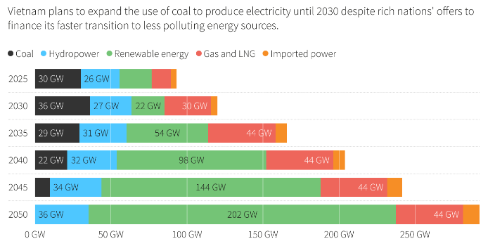

Vietnam’s power plan. Source: [Reuters](https://www.reuters.com/business/cop/vietnam-boosts-coal-use-plan-2030-g7-climate-offer-stalls-2022-11-23/)

[figure not shown]

Now, G-7 countries have approved a deal to provide Vietnam with $15.5 billion to aid their shift towards renewable energy.

This funding comes from both public and private sources over the coming 3-5 years, with the majority coming as loans.

“The investment we are making today means [this emerging economy] can cut its emissions while […] creating new jobs and growth,” says the British Prime Minister.

[Original Article](https://globalnews.ca/news/9347960/g7-vietnam-renewable-energy/)

# Oil

## Weekly Crude Prices

### Feature Crude

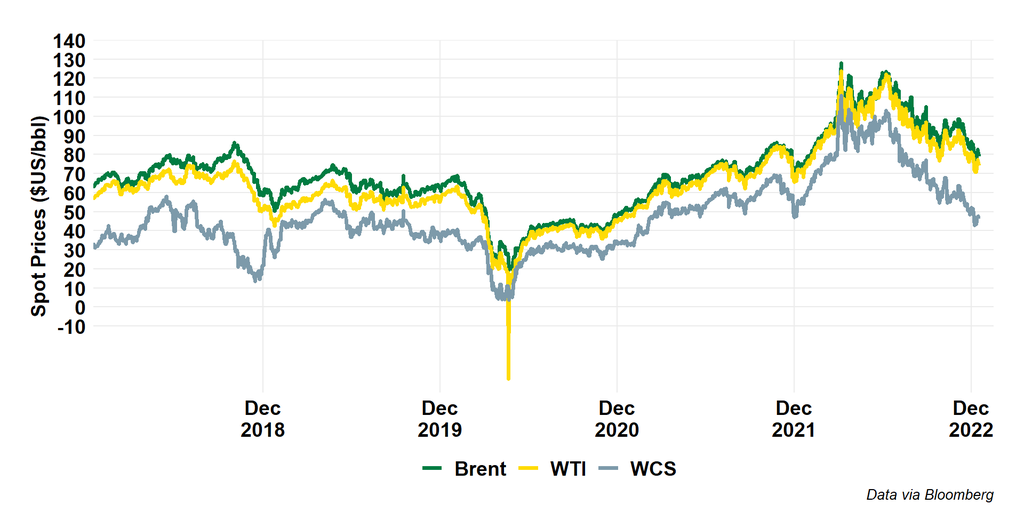

### Alberta Crude

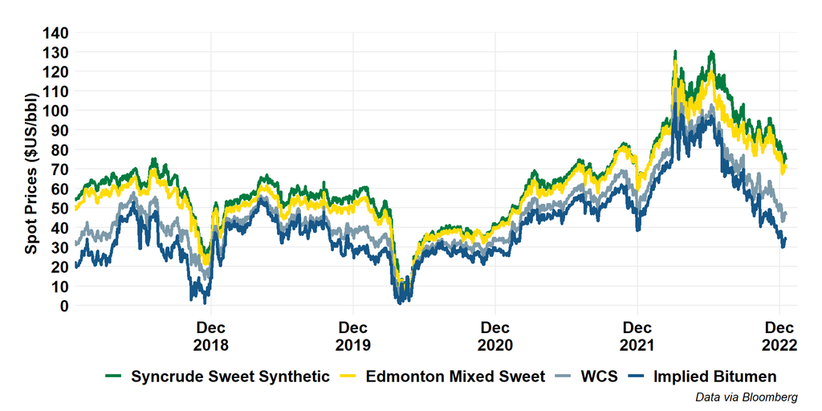

### Alberta Crude (Short)

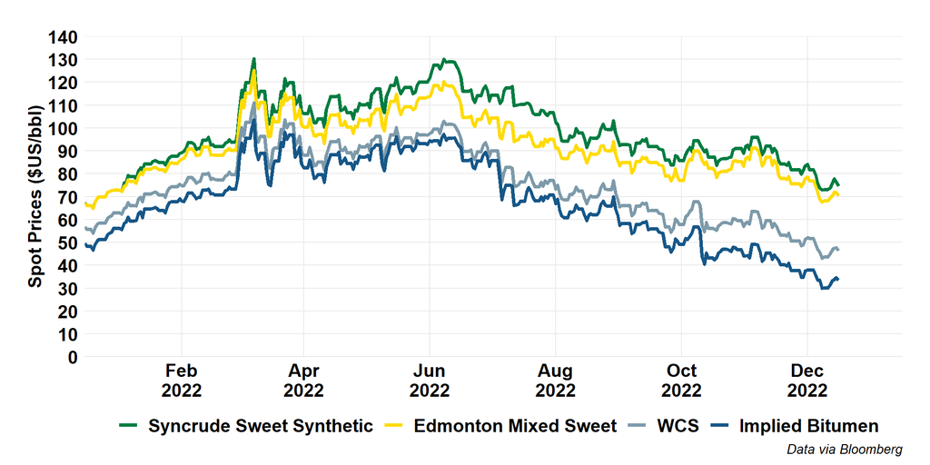

### US Crude

[figure not shown]

### Global Crude

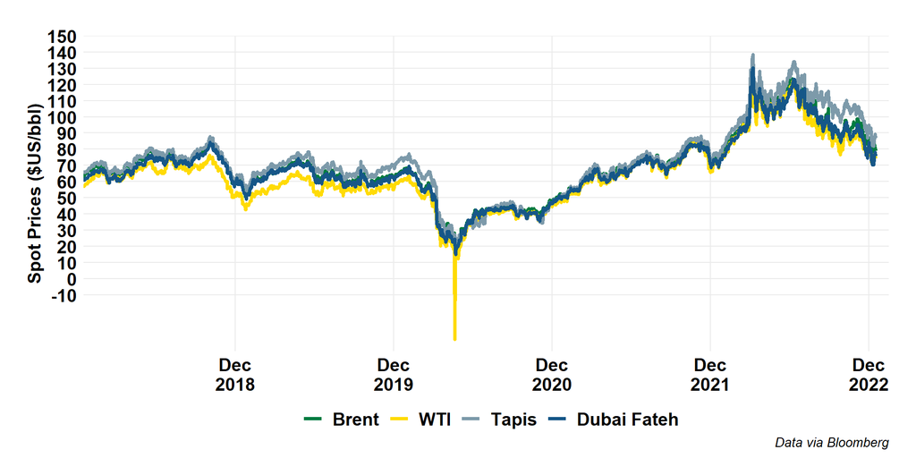

## Oil Price Differentials

### Brent-WTI

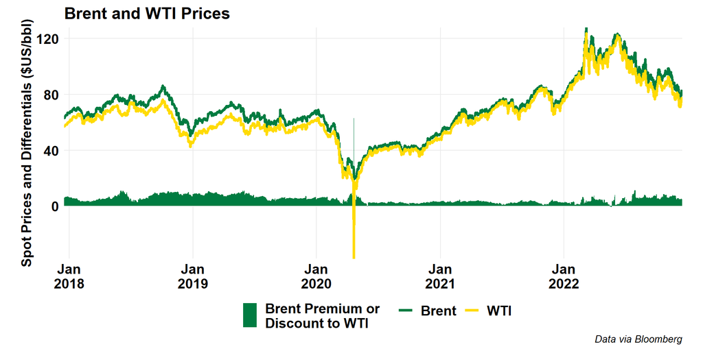

### WTI-WCS

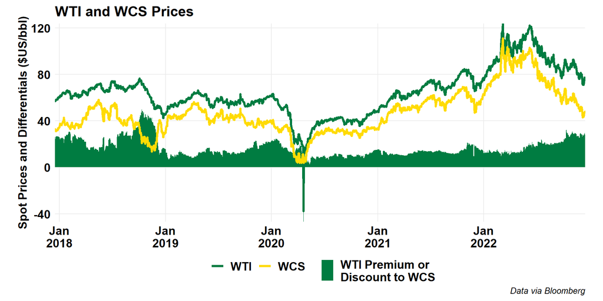

### WTI-WCS (Short)

[figure not shown]

### Maya-WCS

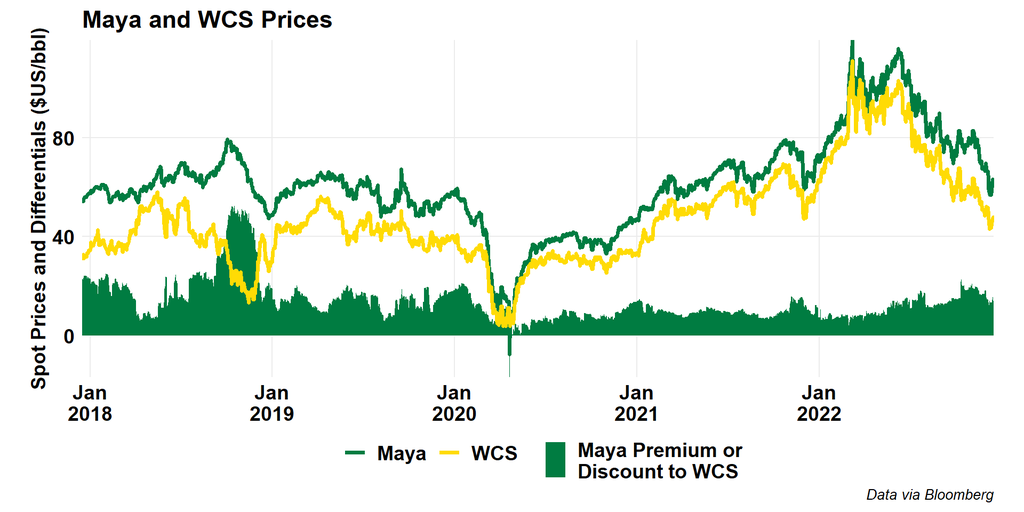

### WTI Cushing vs MEH

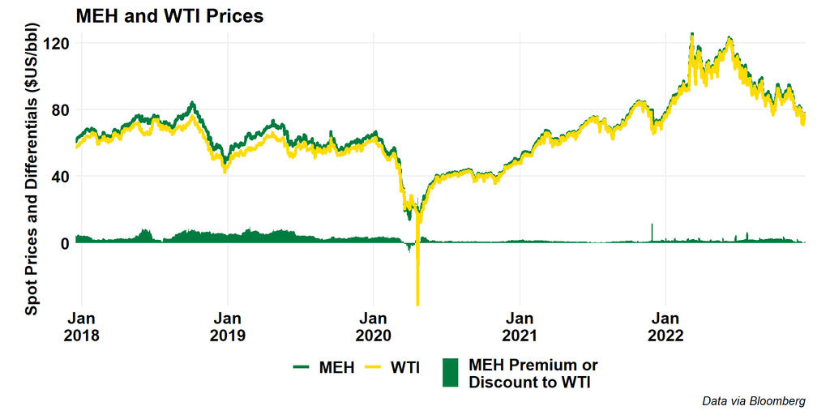

## Forward Curves

### WTI

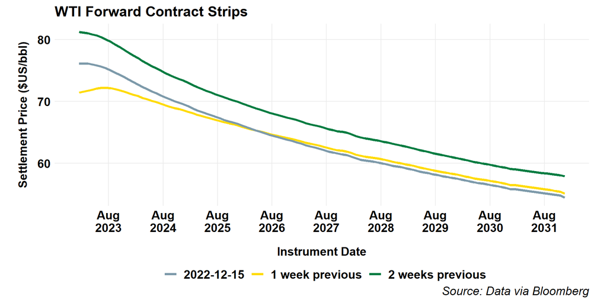

### Brent

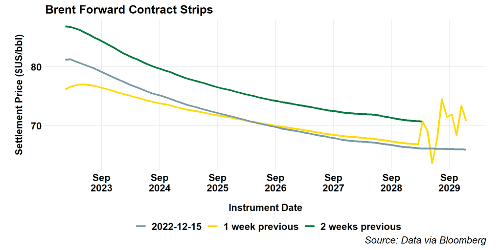